# Objective

# Correlation Plot

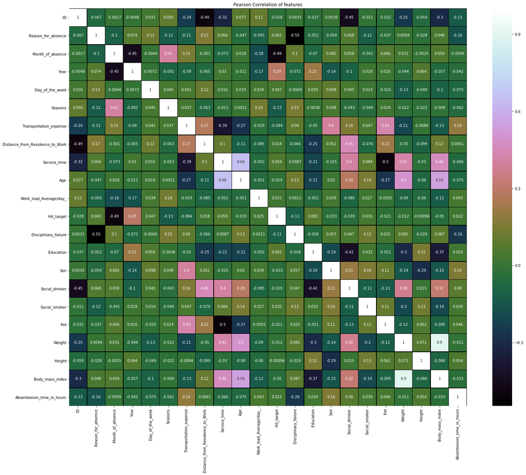

```python
#Correlation Plot
churn_corr = complete_data
#churn_corr = complete_data
#Setting the plot height and width
f, ax = plt.subplots(figsize=(25, 20))

#Generating correlation matrix
corr = churn_corr.corr()

#Ploting using seaborn library
#annot shows the correlation number inside each block
plt.title('Pearson Correlation of features')
correlation_plot = sns.heatmap(corr, linewidths=0.4,vmax=1.0, square=True, cmap="cubehelix", linecolor='k', annot=True)
plt.savefig("correlation_plot.png")
#BMI formula
#(Weight/(Height)2) *703
#A normal BMI ranges from 18.5 to 24.9
#Overweight is defined as having a BMI of 25 to 29.9.
#A BMI equal or greater than 30 is considered obese.
```

**Stability Selection via Randomized Lasso**

```python
# First extract the target variable which is our Absenteeism hours
Y = complete_data.Absenteeism_time_in_hours.values
# Drop Absenteeism_time_in_hours from the complete_data dataframe and create a matrix out of the house data
data_without_target = complete_data.drop(['Absenteeism_time_in_hours'], axis=1)
X = data_without_target.as_matrix()
# Store the column/feature names into a list "colnames"
colnames = data_without_target.columns
```

```python
# Define dictionary to store our rankings
ranks = {}
# Create our function which stores the feature rankings to the ranks dictionary
def ranking(ranks, names, order=1):
    minmax = MinMaxScaler()
    ranks = minmax.fit_transform(order*np.array([ranks]).T).T[0]
    ranks = map(lambda x: round(x,2), ranks)
    return dict(zip(names, ranks))
```

```python
# Finally let's run our Selection Stability method with Randomized Lasso
rlasso = RandomizedLasso(alpha=0.04)
rlasso.fit(X, Y)
ranks["rlasso/Stability"] = ranking(np.abs(rlasso.scores_), colnames)
print('finished')
```

```
finished
```

**2. Recursive Feature Elimination ( RFE )**

```python
# Construct our Linear Regression model
lr = LinearRegression(normalize=True)
lr.fit(X,Y)
#stop the search when only the last feature is left
rfe = RFE(lr, n_features_to_select=1, verbose =3 )
rfe.fit(X,Y)
ranks["RFE"] = ranking(list(map(float, rfe.ranking_)), colnames, order=-1)
```

```
Fitting estimator with 21 features.
Fitting estimator with 20 features.
Fitting estimator with 19 features.
Fitting estimator with 18 features.
Fitting estimator with 17 features.
Fitting estimator with 16 features.
Fitting estimator with 15 features.
Fitting estimator with 14 features.
Fitting estimator with 13 features.
Fitting estimator with 12 features.
Fitting estimator with 11 features.
Fitting estimator with 10 features.
Fitting estimator with 9 features.
Fitting estimator with 8 features.
Fitting estimator with 7 features.
Fitting estimator with 6 features.
Fitting estimator with 5 features.
Fitting estimator with 4 features.
Fitting estimator with 3 features.
Fitting estimator with 2 features.
```

**3. Linear Model Feature Ranking**

```python
# Using Linear Regression
lr = LinearRegression(normalize=True)
lr.fit(X,Y)
ranks["LinReg"] = ranking(np.abs(lr.coef_), colnames)

# Using Ridge
ridge = Ridge(alpha = 7)
ridge.fit(X,Y)
ranks['Ridge'] = ranking(np.abs(ridge.coef_), colnames)

# Using Lasso
lasso = Lasso(alpha=.05)
lasso.fit(X, Y)
ranks["Lasso"] = ranking(np.abs(lasso.coef_), colnames)
```

```python
np.abs(lr.coef_)
```

```
array([  5.02887752e-02,   1.72065978e-01,   4.29796544e-02,
         1.21838380e-01,   6.49135175e-02,   5.99930134e-02,
         3.74472970e-03,   2.44915245e-02,   1.24510774e-01,
         3.77010338e-03,   1.67895582e-06,   6.89387784e-03,
         7.85633753e+00,   8.62201084e-02,   4.33707000e-01,
         8.40243358e-01,   5.93359028e-01,   1.23323756e-01,
         3.33948700e-02,   1.18968304e-01,   1.46851631e-01])
```

**4. Random Forest feature ranking**

```python
rf = RandomForestRegressor(n_jobs=-1, n_estimators=50, verbose=3)
rf.fit(X,Y)
ranks["RF"] = ranking(rf.feature_importances_, colnames);
```

[output not shown]

```
[Parallel(n_jobs=-1)]: Done  24 tasks      | elapsed:    0.1s
[Parallel(n_jobs=-1)]: Done  50 out of  50 | elapsed:    0.2s finished
```

[output not shown]

# 6. Creating the Feature Ranking Matrix

```python
# Create empty dictionary to store the mean value calculated from all the scores
r = {}
for name in colnames:
    r[name] = round(np.mean([ranks[method][name]
                             for method in ranks.keys()]), 2)

methods = sorted(ranks.keys())
ranks["Mean"] = r
methods.append("Mean")

print("\t%s" % "\t".join(methods))
for name in colnames:
    print("%s\t%s" % (name, "\t".join(map(str,
                         [ranks[method][name] for method in methods]))))
```

```
	Lasso	LinReg	RF	RFE	Ridge	rlasso/Stability	Mean
ID	0.01	0.01	0.19	0.35	0.01	0.0	0.1
Reason_for_absence	0.02	0.02	1.0	0.75	0.02	0.0	0.3
Month_of_absence	0.0	0.01	0.22	0.3	0.01	0.0	0.09
Year	0.01	0.02	0.1	0.45	0.02	0.0	0.1
Day_of_the_week	0.01	0.01	0.25	0.65	0.01	0.0	0.16
Seasons	0.01	0.01	0.1	0.7	0.02	0.0	0.14
Transportation_expense	0.0	0.0	0.19	0.05	0.0	0.0	0.04
Distance_from_Residence_to_Work	0.0	0.0	0.09	0.2	0.0	0.0	0.05
Service_time	0.01	0.02	0.06	0.55	0.02	0.0	0.11
Age	0.0	0.0	0.08	0.15	0.0	0.0	0.04
Work_load_Average/day_	0.0	0.0	0.36	0.0	0.0	0.0	0.06
Hit_target	0.0	0.0	0.23	0.1	0.0	0.0	0.06
Disciplinary_failure	1.0	1.0	0.49	1.0	1.0	0.0	0.75
Education	0.0	0.01	0.03	0.8	0.01	0.0	0.14
Son	0.06	0.06	0.06	0.85	0.07	0.0	0.18
Social_drinker	0.03	0.11	0.01	0.9	0.11	0.0	0.19
Social_smoker	0.0	0.08	0.0	0.95	0.06	0.0	0.18
Pet	0.01	0.02	0.01	0.4	0.02	0.0	0.08
Weight	0.0	0.0	0.08	0.25	0.0	0.0	0.06
Height	0.01	0.02	0.13	0.6	0.02	0.0	0.13
Body_mass_index	0.0	0.02	0.12	0.5	0.02	0.0	0.11
```

```python
ranks.keys()
```

```
dict_keys(['rlasso/Stability', 'RFE', 'LinReg', 'Ridge', 'Lasso', 'RF', 'Mean'])
```

```python
# Put the mean scores into a Pandas dataframe
meanplot = pd.DataFrame(list(r.items()), columns= ['Feature','Mean Ranking'])

# Sort the dataframe
meanplot = meanplot.sort_values('Mean Ranking', ascending=False)
```

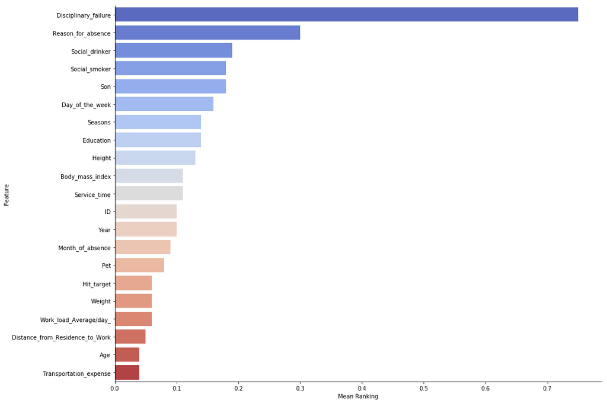

```python
# Let's plot the ranking of the features
plt.figure(figsize=(25,30))
sns.factorplot(x="Mean Ranking", y="Feature", data = meanplot, kind="bar",
               size=10, aspect=1.5, palette='coolwarm')
plt.savefig('feature_importance.png')
```

## Simple Linear Regression

```python
#Grouping the data based on year of month and total absenteeism hour
ts = pd.DataFrame(complete_data.groupby(['Year' , 'Month_of_absence'])['Absenteeism_time_in_hours'].sum())
```

```python
#As linear regression doesn't take date as input converting months into sequence of number starting from 1 to 37( as we have 37 months)
linear_data = pd.DataFrame( {'Month' : range(1,38,1), 'Absenteeism_time_in_hours': ts.Absenteeism_time_in_hours})
linear_data.reset_index(drop = True, inplace = True)
cols_name = linear_data.columns.tolist()
column_to_move = "Month"
new_position = 0
cols_name.insert(new_position, cols_name.pop(cols_name.index(column_to_move)))
linear_data = linear_data[cols_name]
```

```python
linear_data
```

|  | Month | Absenteeism_time_in_hours |
| --- | --- | --- |
| 0 | 1 | 88 |
| 1 | 2 | 109 |
| 2 | 3 | 70 |
| 3 | 4 | 79 |
| 4 | 5 | 82 |
| 5 | 6 | 61 |
| 6 | 7 | 65 |
| 7 | 8 | 87 |
| 8 | 9 | 195 |
| 9 | 10 | 83 |
| 10 | 11 | 58 |
| 11 | 12 | 101 |
| 12 | 13 | 113 |
| 13 | 14 | 66 |
| 14 | 15 | 90 |
| 15 | 16 | 121 |
| 16 | 17 | 89 |
| 17 | 18 | 69 |
| 18 | 19 | 46 |
| 19 | 20 | 89 |
| 20 | 21 | 131 |
| 21 | 22 | 60 |
| 22 | 23 | 75 |
| 23 | 24 | 65 |
| 24 | 25 | 97 |
| 25 | 26 | 76 |
| 26 | 27 | 41 |
| 27 | 28 | 99 |
| 28 | 29 | 88 |
| 29 | 30 | 64 |
| 30 | 31 | 64 |
| 31 | 32 | 101 |
| 32 | 33 | 129 |
| 33 | 34 | 93 |
| 34 | 35 | 133 |
| 35 | 36 | 77 |
| 36 | 37 | 74 |

```python
#Saving the month data into month variable making it as column vector by inserting an axis along second dimension
Month = linear_data['Month'][:, np.newaxis]
#Saving the absenteeism time in another variable
Absenteeism_time_in_hours  = linear_data['Absenteeism_time_in_hours']
```

```python
#Splitting into train and test, with 80:20 ratio
x_train, x_cv, y_train, y_cv = train_test_split(Month, Absenteeism_time_in_hours, test_size = 0.2)
```

```python
#Making  linear regression object
lr = LinearRegression()
#Training the model
fit = lr.fit(x_train, y_train)

b_0   = fit.intercept_
coeff = fit.coef_
print('Intercept:  %.4f' % b_0)
print('Month Coefficient value: ' % coeff)
```

```
Intercept:  92.2478
Month Coefficient value:
```

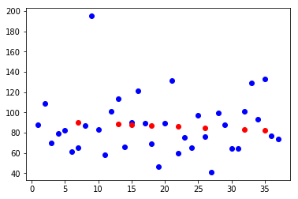

```python
#Making predictions
pred = lr.predict(x_cv)

#Plotting the prediction with the original values plot
plt.scatter(Month, Absenteeism_time_in_hours, color='b')
plt.scatter(x_cv, pred, color='red')
plt.show()
```

```python
#Making the predicted month column vector from 38-55 as we need to predict for till 54(which means December 2011)
predict_month = np.array(
  [a for a in range(38, 55)]
)[:, np.newaxis]

#Forecating the absenteese hour per month
forecast_2011 = lr.predict(predict_month)
forecast_2011
```

```
array([ 81.29624998,  81.00805112,  80.71985227,  80.43165341,
        80.14345456,  79.8552557 ,  79.56705685,  79.27885799,
        78.99065914,  78.70246028,  78.41426143,  78.12606257,
        77.83786372,  77.54966486,  77.26146601,  76.97326715,  76.6850683 ])
```

**Linear Regression Model Performance Measures**

```python
# Adjusted R-square
score = lr.score(Month[:], Absenteeism_time_in_hours[:])
print ('Linear Regression without trend R square: %.4f' % score)
```

```
Linear Regression without trend R square: -0.0091
```

```python
lin_mse = mean_squared_error(pred, y_cv)
lin_rmse = np.sqrt(lin_mse)
print('Linear Regression without trend RMSE: %.4f' % lin_rmse)
```

```
Linear Regression without trend RMSE: 25.5509
```

```python
def mean_absolute_percentage_error(y_true, y_pred):
    y_true, y_pred = np.array(y_true), np.array(y_pred)
    return np.mean(np.abs((y_true - y_pred) / y_true)) * 100

mean_absolute_percentage_error(y_cv, pred)
```

```
24.962022545988123
```

```python
regr = OLS(Absenteeism_time_in_hours, add_constant(Month)).fit()
print("Akaike information criterion: %.4f " %regr.aic)
```

```
Akaike information criterion: 357.1260
```

## Linear Regression with trend

```python
#Lets calculate the trend first and forecast the trend for 2011 year
linear_data.head()
```

|  | Month | Absenteeism_time_in_hours |
| --- | --- | --- |
| 0 | 1 | 88 |
| 1 | 2 | 109 |
| 2 | 3 | 70 |
| 3 | 4 | 79 |
| 4 | 5 | 82 |

We will take out the trend part: A new series is constructed where the value at the current time step is calculated as the difference between the original observation and the observation at the previous time step. How are we going to forecast with trend? *First we will take out the trend part from the series by taking the difference between the original observation and the observation at the previous time step.* Then we will forcast the trend values till December 2011 using the following trend. *Then we will forecast the absenteese hours per month using the month and forecasted trend as predictor variable.

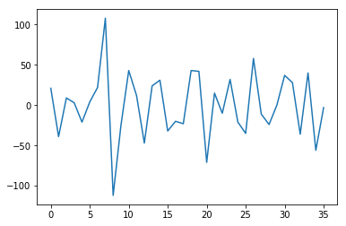

```python
#Taking the trend part out of the series by taking the difference between the original observation and the observation at the
#previous step
X = linear_data.Absenteeism_time_in_hours
diff = list()
for i in range(1, len(X)):
    value = X[i] - X[i - 1]
    diff.append(value)
pyplot.plot(diff)
pyplot.show()
```

```python
#As in diff variable the first observation will be NA to calculate the trend as we need two variables to calculate trend, I'm adding a mean of trend as the first observation
#value for trend so that we can use it in linear regression
aver = np.mean(diff)

#Adding this aver value at start
diff.insert(1, aver)

#Length of trend
len(diff)
```

```
37
```

```python
#Lets make a data frame with trend and month and then forecast the trend
linear_data_trend = pd.DataFrame( {'Month' : range(1,38,1), 'Trend': diff})

#Converting the month to column vector 2D array
Month = linear_data_trend['Month'][:, np.newaxis]
Trend  = linear_data_trend['Trend']
```

```python
#Making the linear regression model
lr = LinearRegression()
#Fitting the model
fit = lr.fit(Month, Trend)

b_0   = fit.intercept_
coeff = fit.coef_
```

```python
#Making the predicted month column vector array from 38-55 as we need to predict trend till 54(which means December 2011)
predict_month_trend = np.array(
  [a for a in range(38, 55)]
)[:, np.newaxis]

#Forecasting the trend till December 2011
forecast_trend = lr.predict(predict_month_trend)
forecast_trend
```

```
array([-1.52577578, -1.58561193, -1.64544808, -1.70528423, -1.76512038,
       -1.82495654, -1.88479269, -1.94462884, -2.00446499, -2.06430114,
       -2.1241373 , -2.18397345, -2.2438096 , -2.30364575, -2.3634819 ,
       -2.42331805, -2.48315421])
```

```python
#Lets make a new Data frame with Month, trend and Absenteese hours
linear_TA = pd.DataFrame({'Month' : range(1,38,1), 'Trend': diff , 'Absenteeism_time_in_hours': linear_data.Absenteeism_time_in_hours})
```

```python
#Saving the predictor variables into a new variable
X = linear_TA.loc[:,['Month','Trend']]
#Splitting into train and test. 80:20
x_train, x_cv, y_train, y_cv = train_test_split(X, linear_TA.Absenteeism_time_in_hours, test_size = 0.2)
```

```python
#Training the model
fit_tren = lr.fit(x_train, y_train)

#Predicting the absentese hours for the test feature i.e Month and trend
pred = lr.predict(x_cv)
```

```python
print("Estimated intercept coefficient", lr.intercept_)
print('Number of coefficients', len(lr.coef_))
print("Coefficients Values" , lr.coef_)
```

```
Estimated intercept coefficient 86.0588288525
Number of coefficients 2
Coefficients Values [ 0.13118818  0.50721732]
```

```python
#Making the dataframe with forecasted trend and the month
predict_trend = pd.DataFrame({'Month': range(38,55,1), 'Trend' : forecast_trend})

#Forecast with trend
forecast_2011 = lr.predict(predict_trend)
forecast_2011
```

```
array([ 90.27007985,  90.37091809,  90.47175634,  90.57259459,
        90.67343284,  90.77427109,  90.87510934,  90.97594759,
        91.07678584,  91.17762408,  91.27846233,  91.37930058,
        91.48013883,  91.58097708,  91.68181533,  91.78265358,  91.88349182])
```

**Model Performance Evaluation**

```python
#Getting the R square score
score = lr.score(x_train, y_train)
print ('Linear Regression without trend R square: %.4f' % score)
```

```
Linear Regression without trend R square: 0.5078
```

```python
#Calculating the Root mean square error
lin_mse = mean_squared_error(pred, y_cv)
lin_rmse = np.sqrt(lin_mse)
print('Linear Regression RMSE: %.4f' % lin_rmse)
```

```
Linear Regression RMSE: 18.5194
```

```python
def mean_absolute_percentage_error(y_true, y_pred):
    y_true, y_pred = np.array(y_true), np.array(y_pred)
    return np.mean(np.abs((y_true - y_pred) / y_true)) * 100

mean_absolute_percentage_error(y_cv, pred)
```

```
19.289117217330691
```

```python
#AIC Score
regr = OLS(y_train, add_constant(x_train)).fit()
print('Akaike information criterion: %.4f' % regr.aic)
```

```
Akaike information criterion: 265.6515
```

## Time Series Analysis

```python
ts = complete_data.groupby(['Year' , 'Month_of_absence'])['Absenteeism_time_in_hours'].sum()
```

```python
ts.index=pd.date_range(start = '2007-07-01',end='2010-08-01', freq = 'M')
```

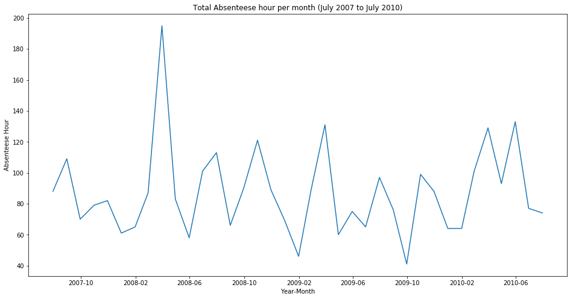

```python
ts.astype('float')
plt.figure(figsize=(16,8))
plt.title('Total Absenteese hour per month (July 2007 to July 2010)')
plt.xlabel('Year-Month')
plt.ylabel('Absenteese Hour')
plt.plot(ts)
plt.savefig('TotalAbsenteesehr_permonth.png')
```

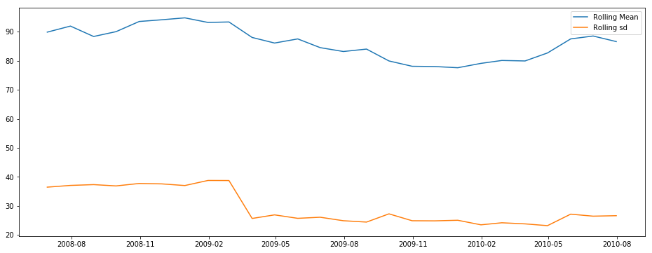

```python
#Rolling mean and sd for year
plt.figure(figsize=(16,6))
#As we have a small time series we are checking the rolling mean and sd.
plt.plot(ts.rolling(window=12,center=False).mean(),label='Rolling Mean')
plt.plot(ts.rolling(window=12,center=False).std(),label='Rolling sd')
plt.legend()
plt.savefig('Rolling_means_sd.png')
```

Let's check that with a quick decomposition into Trend, seasonality and residuals.

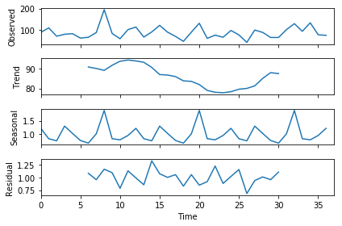

```python
# multiplicative
res = sm.tsa.seasonal_decompose(ts.values,freq=12,model="multiplicative")
#plt.figure(figsize=(16,12))
fig = res.plot()
plt.savefig("Decomposition.png")
#fig.show()
```

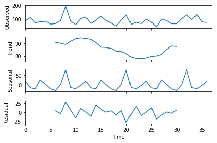

```python
# Additive model
res = sm.tsa.seasonal_decompose(ts.values,freq=12,model="additive")
#plt.figure(figsize=(16,12))
fig = res.plot()
plt.savefig('Decomposition_add.png')
#fig.show()
```

## Stationarity:

A TS is said to be stationary if its statistical properties such as mean, variance remain constant over time Stationarity refers to time-invariance of a series. (ie) Two points in a time series are related to each other by only how far apart they are, and not by the direction(forward/backward)

When a time series is stationary, it can be easier to model. Statistical modeling methods assume or require the time series to be stationary.

We will implement ADF( Augmented Dicky Fuller Test), one of the statistical test to check the staionarity in the data.

# Dickey-Fuller Test:

This is one of the statistical tests for checking stationarity. Here the null hypothesis is that the TS is non-stationary. The test results comprise of a Test Statistic and some Critical Values for difference confidence levels. If the ‘Test Statistic’ is less than the ‘Critical Value’, we can reject the null hypothesis and say that the series is stationary

```python
# Stationarity tests
def test_stationarity(timeseries):

    #Perform Dickey-Fuller test:
    print('Results of Dickey-Fuller Test:')
    dftest = adfuller(timeseries, autolag='AIC')
    dfoutput = pd.Series(dftest[0:4], index=['Test Statistic','p-value','#Lags Used','Number of Observations Used'])
    for key,value in dftest[4].items():
        dfoutput['Critical Value (%s)'%key] = value
    print (dfoutput)

test_stationarity(ts)
```

```
Results of Dickey-Fuller Test:
Test Statistic                -5.702235e+00
p-value                        7.629028e-07
#Lags Used                     1.000000e+00
Number of Observations Used    3.500000e+01
Critical Value (1%)           -3.632743e+00
Critical Value (5%)           -2.948510e+00
Critical Value (10%)          -2.613017e+00
dtype: float64
```

**As our p-value is lower than 0.05 which means we can reject the null hypothesis and accept the alternate hypothesis, which says tht the data is stationary.** **As our time series already seems to be stationary, there is no need to perform actions to make it stationary**

## Forecasting a Time Series

**Using ARIMA**

## ACF AND PACF

```python
#PACF plot tells about p; autoregression part
#ACF plot tells about q: Moving average part
```

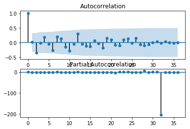

```python
pyplot.figure()
pyplot.subplot(211)
plot_acf(ts, ax=pyplot.gca())
pyplot.subplot(212)
plot_pacf(ts, ax=pyplot.gca())
pyplot.show()
```

## Seasonal ARIMA

```python
train = pd.DataFrame(ts[0:30])
test = pd.DataFrame(ts[30:37])
```

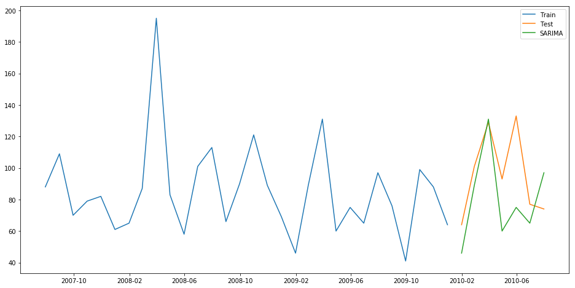

```python
y_hat_avg = test.copy()
#we are using the same order as used in ARIMA in R with seasonal difference
#(p,d,q) are non seasonal paramters
#(P,D,Q,freq) are seasonal parameters, as we have used 1 seasonal differencing and 12 as we have monthly data
history = [x for x in train]
fit1 = sm.tsa.statespace.SARIMAX(train.Absenteeism_time_in_hours, order=(0, 0, 0),seasonal_order=(0,1,0,12)).fit()
y_hat_avg['SARIMA'] = fit1.predict(start="2010-01-31", end= "2011-12-31", dynamic=True)
plt.figure(figsize=(16,8))
plt.plot( train['Absenteeism_time_in_hours'], label='Train')
plt.plot(test['Absenteeism_time_in_hours'], label='Test')
plt.plot(y_hat_avg['SARIMA'], label='SARIMA')
plt.legend(loc='best')
plt.show()
```

**Model Performance**

```python
#Root mean square error
rms = np.sqrt(mean_squared_error(test.Absenteeism_time_in_hours, y_hat_avg.SARIMA))
print("Root mean square error for SARIMA: %.4f" % rms)
```

```
Root mean square error for SARIMA: 28.2792
```

```python
#Mean Percentage Absolute error
mape = mean_absolute_percentage_error(test.Absenteeism_time_in_hours, y_hat_avg.SARIMA)
print("Mean Absolute Percentage error for SARIMA: %.4f" % rms)
```

```
Mean Absolute Percentage error for SARIMA: 28.2792
```

```python
y_hat_avg['SARIMA'] = fit1.predict(start="2010-1-31", end="2011-12-31")
y_hat_avg['SARIMA']
```

```
2010-01-31     46.0
2010-02-28     89.0
2010-03-31    131.0
2010-04-30     60.0
2010-05-31     75.0
2010-06-30     65.0
2010-07-31     97.0
Freq: M, Name: SARIMA, dtype: float64
```